# Module 11 Analysis

Savannah Hammerton

11/2/2021

## Feature/Variable Removal

I need to remove all Yes/No versions of variables that also exist as multiple level variables. Then, I need to code the three ordinal factors as ordered, in the proper order.

```r
#remove yes/no version of multi-level variables - CoughYN, WeaknessYN, CoughYN2, MyalgiaYN
mydata.2 <- mydata %>%
  select(!c(CoughYN, CoughYN2, WeaknessYN, MyalgiaYN))

#checking to see if ordinal factors are coded as ordered - Weakness, CoughIntensity, Myalgia
is.ordered(mydata.2$Weakness)
```

```
## [1] FALSE
```

```r
is.ordered(mydata.2$CoughIntensity)
```

```
## [1] FALSE
```

```r
is.ordered(mydata.2$Myalgia)
```

```
## [1] FALSE
```

```r
#code ordinal/multi-level factors as ordered factors and check order is None/Mild/Moderate/Severe
mydata.3 <- mydata.2 %>%
  mutate(Weakness = ordered(Weakness, levels = c('None', 'Mild', 'Moderate', 'Severe'))) %>%
  mutate(CoughIntensity = ordered(CoughIntensity, levels = c('None', 'Mild', 'Moderate', 'Severe'))) %>%
  mutate(Myalgia = ordered(Myalgia, levels = c('None', 'Mild', 'Moderate', 'Severe')))

#checking if new variables are coded as ordered
is.ordered(mydata.3$Weakness)
```

```
## [1] TRUE
```

```r
is.ordered(mydata.3$CoughIntensity)
```

```
## [1] TRUE
```

```r
is.ordered(mydata.3$Myalgia)
```

```
## [1] TRUE
```

## Low variance predictors

I need to remove all binary predictors that have less than <50 entries in one of the categories. To do that, I first need to see what predictors fall into that category. Then I’ll remove them from the data set.

```r
# create summary table to see what binary predictors have <50 in one category
mydata.3 %>%
  select(!c(Weakness, CoughIntensity, Myalgia, BodyTemp)) %>% #removing all non-binary predictors
  gtsummary::tbl_summary() #create summary table
```

| **Characteristic** | **N = 730**<sup>1</sup> |
| --- | --- |
| Swollen Lymph Nodes | 312 (43%) |
| Chest Congestion | 407 (56%) |
| Chills/Sweats | 600 (82%) |
| Nasal Congestion | 563 (77%) |
| Sneeze | 391 (54%) |
| Fatigue | 666 (91%) |
| Subjective Fever | 500 (68%) |
| Headache | 615 (84%) |
| Runny Nose | 519 (71%) |
| Abdominal Pain | 91 (12%) |
| Chest Pain | 233 (32%) |
| Diarrhea | 99 (14%) |
| Eye Pain | 113 (15%) |
| Sleeplessness | 415 (57%) |
| Itchy Eyes | 179 (25%) |
| Nausea | 255 (35%) |
| Ear Pain | 162 (22%) |
| Loss of Hearing | 30 (4.1%) |
| Sore Throat | 611 (84%) |
| Breathlessness | 294 (40%) |
| Tooth Pain | 165 (23%) |
| Blurred Vision | 19 (2.6%) |
| Vomiting | 78 (11%) |
| Wheezing | 220 (30%) |

<sup>*1*</sup> n (%)

```r
# binary predictors with <50 in one category: Loss of Hearing, Blurred Vision
# need to remove those two variables
mydata.4 <- mydata.3 %>%
  select(!c(Hearing, Vision))

# Should have 730 observations and 26 variables - checking
dim(mydata.4) #this looks right!
```

```
## [1] 730  26
```

```r
# setting to final object name
mydata.fin <- mydata.4
```

## Data setup

```r
# set seed to fix random numbers
set.seed(123)

# put 70% of data into training set
data_split <- initial_split(mydata.fin,
                            prop = 7/10, #split data set into 70% training, 30% testing
                            strata = BodyTemp) #use bodytemp as stratification

# create data frames for training and testing sets
train_data <- training(data_split)
test_data <- testing(data_split)

# create a resample object for the training data; 5x5, stratify on bodytemp
cv5 <- vfold_cv(train_data,
                v = 5,
                repeats = 5,
                strata = BodyTemp)

# create a recipe for the data and fitting; code categorical variables as dummy variables
temp_rec <- recipes::recipe(BodyTemp ~ .,
                            data = train_data) %>%
  step_dummy(all_predictors())

# linear model specification
linear_reg_lm_spec <-
  linear_reg() %>%
  set_engine('lm')
```

## Null model performance

```r
#compute the performance of a null model with no predictor information - train data
null_mod_train <- lm(BodyTemp ~ 1, data = train_data)
summary(null_mod_train)
```

```
##
## Call:
## lm(formula = BodyTemp ~ 1, data = train_data)
##
## Residuals:
##     Min      1Q  Median      3Q     Max
## -1.6364 -0.7364 -0.4364  0.3636  4.1636
##
## Coefficients:
##             Estimate Std. Error t value Pr(>|t|)
## (Intercept) 98.93642    0.05371    1842   <2e-16 ***
## ---
## Signif. codes:  0 '***' 0.001 '**' 0.01 '*' 0.05 '.' 0.1 ' ' 1
##
## Residual standard error: 1.211 on 507 degrees of freedom
```

```r
mean(train_data$BodyTemp) #checking the mean of body temp is the same as the bodytemp coefficient in the null model
```

```
## [1] 98.93642
```

```r
#calculate RMSE
null_mod_train %>%
  augment(newdata = train_data) %>%
  rmse(truth = BodyTemp, estimate = .fitted)
```

```
## # A tibble: 1 × 3
##   .metric .estimator .estimate
##   <chr>   <chr>          <dbl>
## 1 rmse    standard        1.21
```

```r
#compute the performance of a null model with no predictor information - test data
null_mod_test <- lm(BodyTemp ~ 1, data = test_data)
summary(null_mod_test)
```

```
##
## Call:
## lm(formula = BodyTemp ~ 1, data = test_data)
##
## Residuals:
##    Min     1Q Median     3Q    Max
## -1.732 -0.732 -0.432  0.368  4.068
##
## Coefficients:
##             Estimate Std. Error t value Pr(>|t|)
## (Intercept) 98.93198    0.07825    1264   <2e-16 ***
## ---
## Signif. codes:  0 '***' 0.001 '**' 0.01 '*' 0.05 '.' 0.1 ' ' 1
##
## Residual standard error: 1.166 on 221 degrees of freedom
```

```r
mean(test_data$BodyTemp) #checking the mean of body temp is the same as the bodytemp coefficient in the null model
```

```
## [1] 98.93198
```

```r
#calculate RMSE
null_rmse <- null_mod_test %>%
  augment(newdata = test_data) %>%
  rmse(truth = BodyTemp, estimate = .fitted) %>%
  mutate(model = 'Null Model')
```

## Model tuning and fitting

1. Define the model specification
2. Create a workflow
3. Create a tuning grid and tune the hyperparameters
4. Autoplot the results
5. Finalize the workflow
6. Fit the model to the training data
7. Estimate model performance with RMSE
8. Make diagnostic plots

Do these steps for each model (tree, LASSO, random forest)

look at rmses for all models (including null) together - choose best performing model, fit to test data, then repeat 7 and 8

### Tree

```r
# 1) define model spec
tree_tune_spec <- decision_tree(
  cost_complexity = tune(),
  tree_depth = tune()) %>%
  set_engine('rpart') %>%
  set_mode('regression')
tree_tune_spec
```

```
## Decision Tree Model Specification (regression)
##
## Main Arguments:
##   cost_complexity = tune()
##   tree_depth = tune()
##
## Computational engine: rpart
```

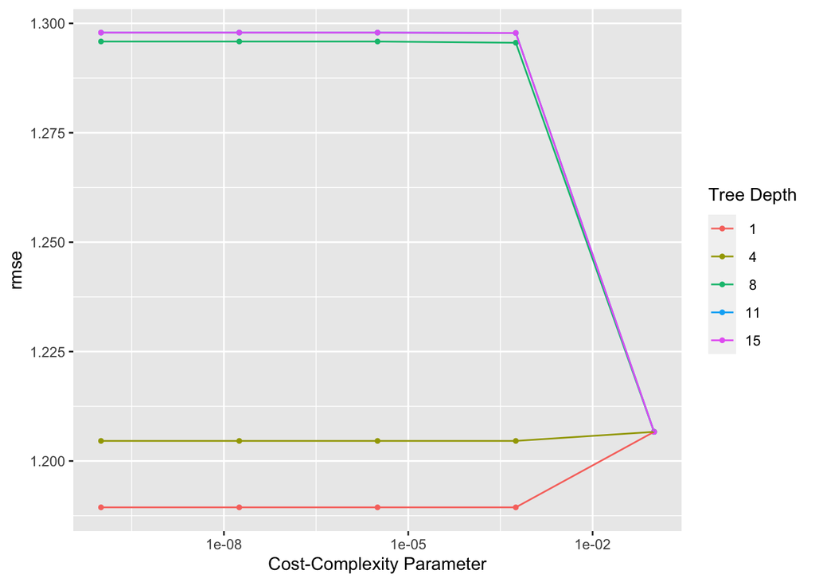

```r
# 2) workflow
tree_wflow <- workflow() %>%
  add_model(tree_tune_spec) %>%
  add_recipe(temp_rec)


# 3) create tuning grid
tree_grid <- grid_regular(cost_complexity(),
                          tree_depth(),
                          levels = 5)

# tune hyperparameters
tree_res <- tree_wflow %>%
  tune_grid(resamples = cv5,
            grid = tree_grid,
            metrics = metric_set(rmse),
            control = control_grid(verbose = T))
# 4) autoplot the results
tree_res %>% autoplot()
```

```r
# 5) finalize the workflow
## select best hyperparameter combination
happy_tree <- tree_res %>%
  select_best()
happy_tree
```

```
## # A tibble: 1 × 3
##   cost_complexity tree_depth .config
##             <dbl>      <int> <chr>
## 1    0.0000000001          1 Preprocessor1_Model01
```

```r
## finalize workflow
happy_tree_wflow <- tree_wflow %>%
  finalize_workflow(happy_tree)

fit_train_happy_tree <- happy_tree_wflow %>%
  fit(data = train_data)

# 6) fit the model to training data
# Use a trained workflow to predict section using test data
predict(fit_train_happy_tree, new_data = train_data)
```

```
## # A tibble: 508 × 1
##    .pred
##    <dbl>
##  1  99.2
##  2  99.2
##  3  98.7
##  4  98.7
##  5  98.7
##  6  98.7
##  7  98.7
##  8  99.2
##  9  99.2
## 10  99.2
## # … with 498 more rows
```

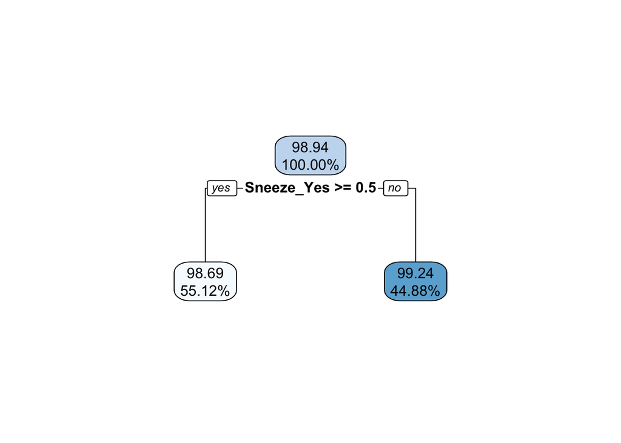

```r
# include predicted probabilities
aug_train_happy_tree <- augment(fit_train_happy_tree, new_data = train_data)

# 7) estimate model performance with rmse
tree_rmse <- aug_train_happy_tree %>%
  rmse(truth = BodyTemp, .pred) %>%
  mutate(model = 'Regression Tree')

# 8) Make diagnostic plots
## view decision tree
extract_fit_engine(fit_train_happy_tree) |> rpart.plot::rpart.plot(digits = 4)
```

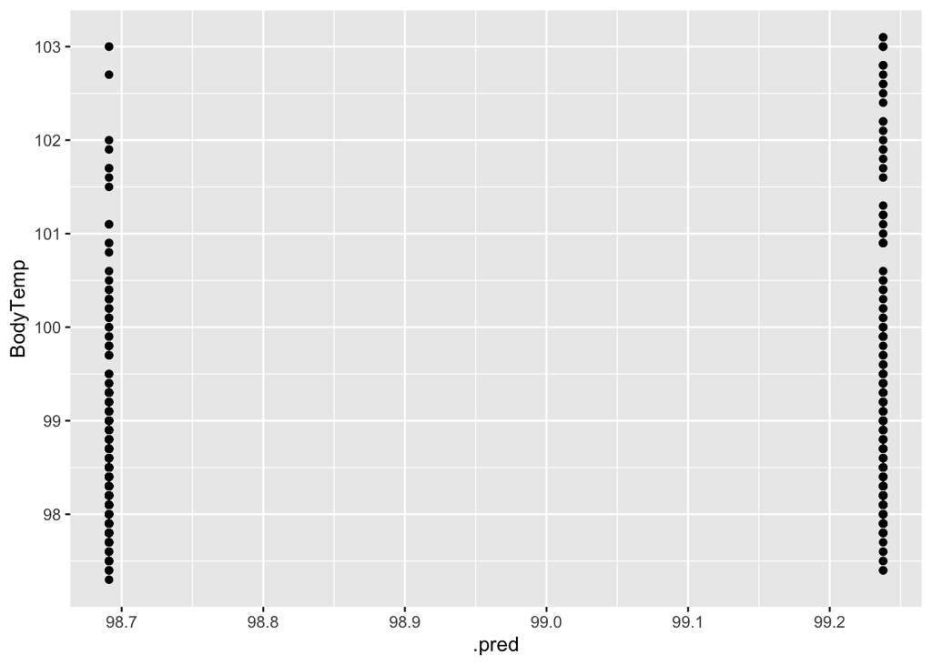

```r
#plot actual vs fitted
ggplot(data = aug_train_happy_tree, aes(x = .pred, y = BodyTemp)) +
  geom_point()
```

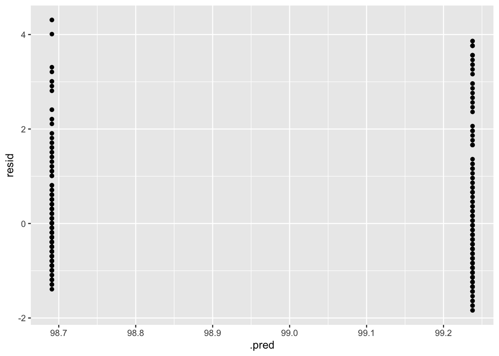

```r
#plot residuals vs fitted
aug_train_happy_tree %>%
  mutate(resid = BodyTemp - .pred) %>%
  ggplot(aes(x = .pred, y = resid)) +
  geom_point()
```

```r
# 1) define model spec
lasso_tune_spec <- linear_reg(
  penalty = tune(), mixture = 1) %>%
  set_engine('glmnet')
lasso_tune_spec
```

```
## Linear Regression Model Specification (regression)
##
## Main Arguments:
##   penalty = tune()
##   mixture = 1
##
## Computational engine: glmnet
```

```r
# 2) workflow
lasso_wflow <- workflow() %>%
  add_model(lasso_tune_spec) %>%
  add_recipe(temp_rec)


# 3) create tuning grid
lasso_grid <- tibble(penalty = 10^seq(-4, -1, length.out = 30))

lasso_grid %>% top_n(-5)
```

```
## # A tibble: 5 × 1
##    penalty
##      <dbl>
## 1 0.0001
## 2 0.000127
## 3 0.000161
## 4 0.000204
## 5 0.000259
```

```r
lasso_grid %>% top_n(5)
```

```
## # A tibble: 5 × 1
##   penalty
##     <dbl>
## 1  0.0386
## 2  0.0489
## 3  0.0621
## 4  0.0788
## 5  0.1
```

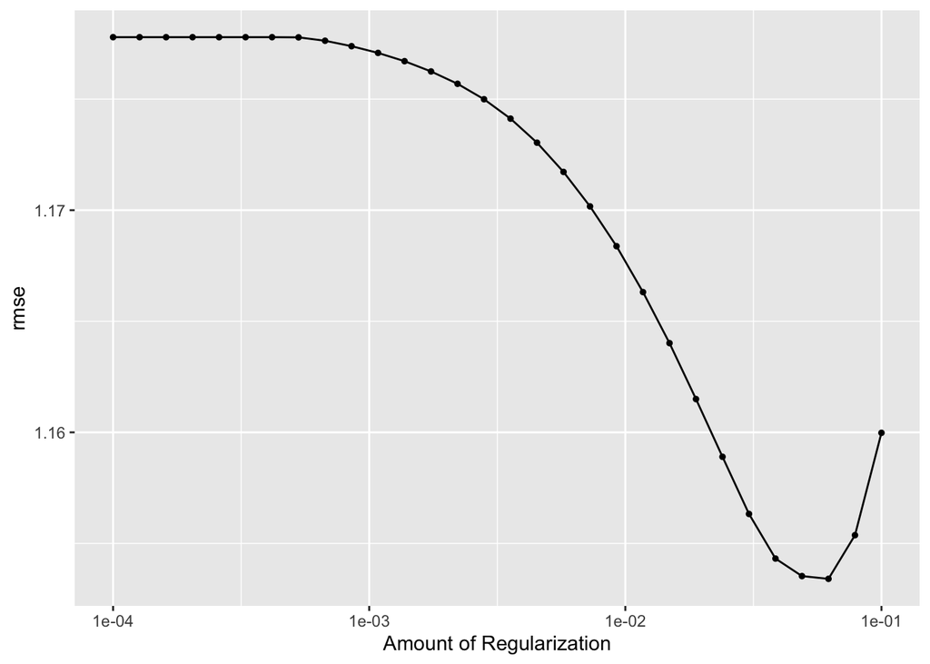

```r
# tune hyperparameters
lasso_res <- lasso_wflow %>%
  tune_grid(resample = cv5,
            grid = lasso_grid,
            control = control_grid(save_pred = T, verbose = T),
            metrics = metric_set(rmse))

# 4) autoplot the results
lasso_res %>% autoplot()
```

```r
#5) finalize the workflow
# select best hyperparameter combination
best_lasso <- lasso_res %>%
  select_best()
best_lasso
```

```
## # A tibble: 1 × 2
##   penalty .config
##     <dbl> <chr>
## 1  0.0621 Preprocessor1_Model28
```

```r
# finalize workflow
best_lasso_wflow <- lasso_wflow %>%
  finalize_workflow(best_lasso)

fit_best_lasso <- best_lasso_wflow %>%
  fit(data = train_data)

#6) fit the model to the test data
# Use a trained workflow to predict section using train data
predict(fit_best_lasso, new_data = train_data)
```

```
## # A tibble: 508 × 1
##    .pred
##    <dbl>
##  1  98.8
##  2  98.8
##  3  98.5
##  4  98.8
##  5  98.7
##  6  98.7
##  7  98.4
##  8  99.3
##  9  98.9
## 10  99.0
## # … with 498 more rows
```

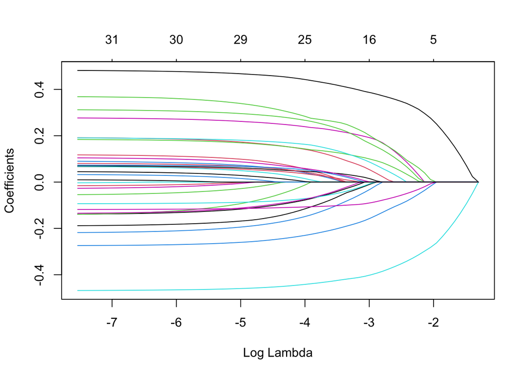

```r
# include predicted probabilities
aug_best_lasso <- augment(fit_best_lasso, new_data = train_data)

# estimate model performance with rmse
lasso_rmse <- aug_best_lasso %>%
  rmse(truth = BodyTemp, .pred) %>%
  mutate(model = 'LASSO')

# 8) Make diagnostic plots
## view coefficient values vs penalty terms
extract_fit_engine(fit_best_lasso) |> plot('lambda')
```

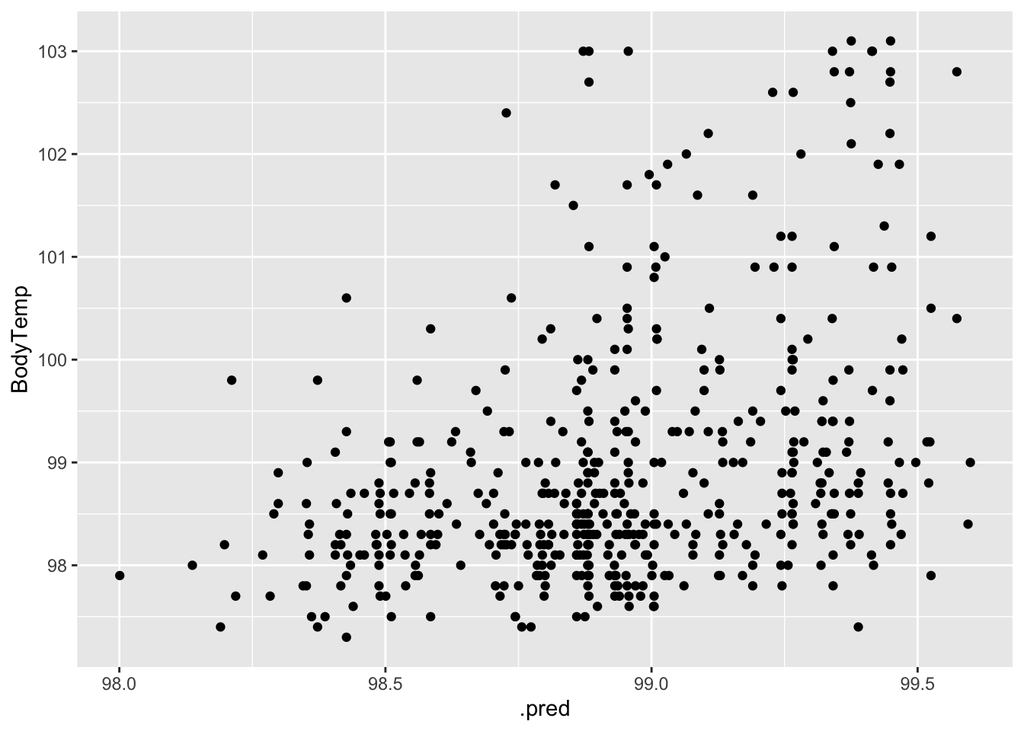

```r
#plot actual vs fitted
ggplot(data = aug_best_lasso, aes(x = .pred, y = BodyTemp)) +
  geom_point()
```

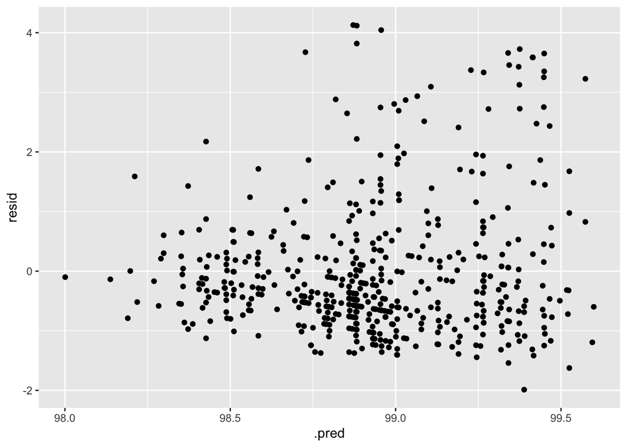

```r
#plot residuals vs fitted
aug_best_lasso %>%
  mutate(resid = BodyTemp - .pred) %>%
  ggplot(aes(x = .pred, y = resid)) +
  geom_point()
```

```r
#cores <- parallel::detectCores()
#cores

# 1) define model spec
forest_spec <-
  rand_forest(
    mtry = tune(),
    min_n = tune(),
    trees = 1000
    ) %>%
  set_engine('ranger',
             num.threads = 1) %>%
  set_mode('regression')
forest_spec
```

```
## Random Forest Model Specification (regression)
##
## Main Arguments:
##   mtry = tune()
##   trees = 1000
##   min_n = tune()
##
## Engine-Specific Arguments:
##   num.threads = 1
##
## Computational engine: ranger
```

```r
# 2) workflow
forest_wflow <- workflow() %>%
  add_model(forest_spec) %>%
  add_recipe(temp_rec)


# 3/4) create tuning grid/tune hyperparameters
forest_spec %>% parameters()
```

```
## Collection of 2 parameters for tuning
##
##  identifier  type    object
##        mtry  mtry nparam[?]
##       min_n min_n nparam[+]
##
## Model parameters needing finalization:
##    # Randomly Selected Predictors ('mtry')
##
## See `?dials::finalize` or `?dials::update.parameters` for more information.
```

```r
forest_res <- forest_wflow %>%
  tune_grid(resample = cv5,
            grid = 25,
            metrics = metric_set(rmse),
            control = control_grid(save_pred = T, verbose = T))


forest_res %>% show_best(metric = "rmse")
```

```
## # A tibble: 5 × 8
##    mtry min_n .metric .estimator  mean     n std_err .config
##   <int> <int> <chr>   <chr>      <dbl> <int>   <dbl> <chr>
## 1     6    35 rmse    standard    1.16    25  0.0166 Preprocessor1_Model20
## 2     8    38 rmse    standard    1.17    25  0.0167 Preprocessor1_Model16
## 3     2    16 rmse    standard    1.17    25  0.0167 Preprocessor1_Model01
## 4     3    10 rmse    standard    1.17    25  0.0163 Preprocessor1_Model14
## 5    10    28 rmse    standard    1.17    25  0.0167 Preprocessor1_Model23
```

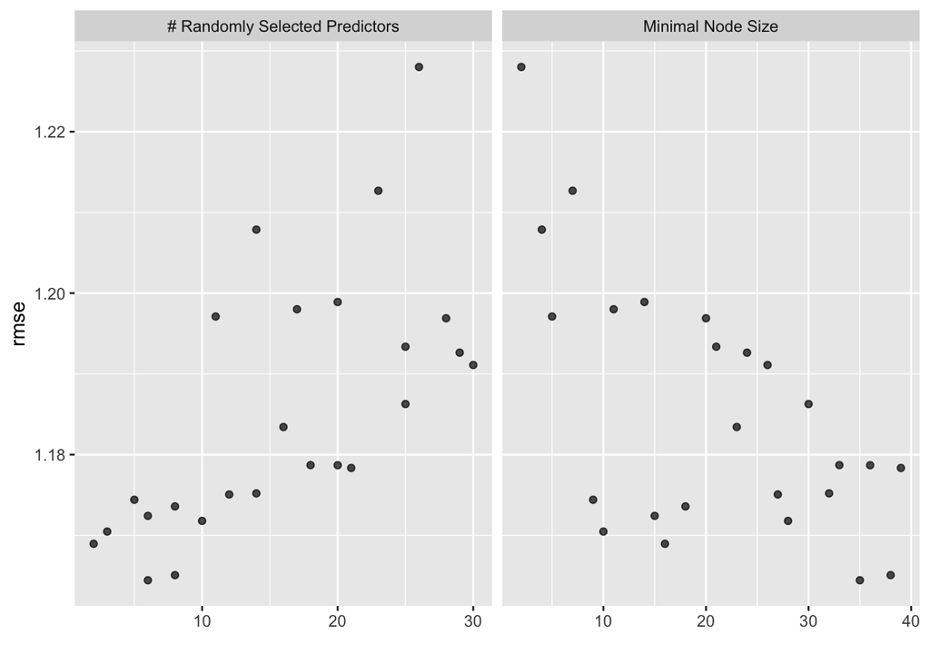

```r
# 5) autoplot the results
forest_res %>% autoplot()
```

```r
# select best hyperparameter combination
best_forest <- forest_res %>%
  select_best()
best_forest
```

```
## # A tibble: 1 × 3
##    mtry min_n .config
##   <int> <int> <chr>
## 1     6    35 Preprocessor1_Model20
```

```r
# finalize workflow
best_forest_wflow <- forest_wflow %>%
  finalize_workflow(best_forest)

fit_best_forest <- best_forest_wflow %>%
  fit(data = train_data)

# Use a trained workflow to predict section using train data
predict(fit_best_forest, new_data = train_data)
```

```
## # A tibble: 508 × 1
##    .pred
##    <dbl>
##  1  98.7
##  2  98.6
##  3  98.7
##  4  98.7
##  5  98.8
##  6  98.6
##  7  98.3
##  8  99.1
##  9  98.8
## 10  98.9
## # … with 498 more rows
```

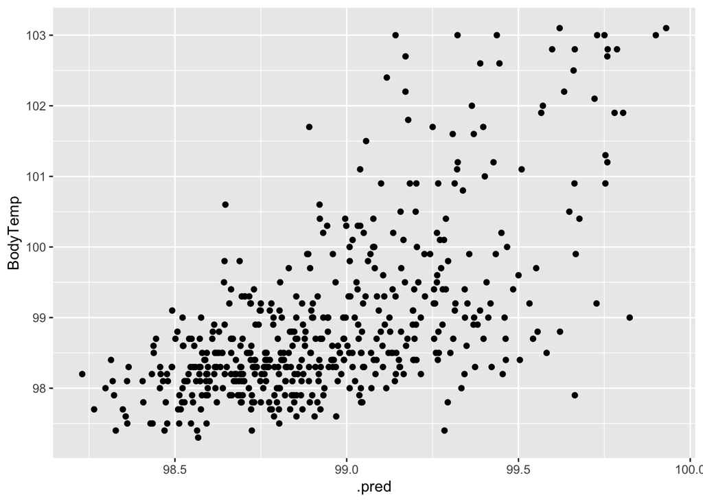

```r
# include predicted probabilities
aug_best_forest <- augment(fit_best_forest, new_data = train_data)

# estimate model performance with rmse
forest_rmse <- aug_best_forest %>%
  rmse(truth = BodyTemp, .pred) %>%
  mutate(model = 'Random Forest')

# 8) Make diagnostic plots

#plot actual vs fitted
ggplot(data = aug_best_forest, aes(x = .pred, y = BodyTemp)) +
  geom_point()
```

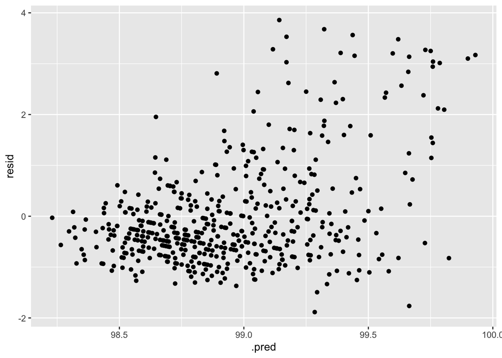

```r
#plot residuals vs fitted
aug_best_forest %>%
  mutate(resid = BodyTemp - .pred) %>%
  ggplot(aes(x = .pred, y = resid)) +
  geom_point()
```

```r
#view RMSEs of all four models
knitr::kable(rbind(null_rmse, tree_rmse, lasso_rmse, forest_rmse))
```

| .metric | .estimator | .estimate | model |
| --- | --- | --- | --- |
| rmse | standard | 1.163334 | Null Model |
| rmse | standard | 1.178367 | Regression Tree |
| rmse | standard | 1.131147 | LASSO |
| rmse | standard | 1.026835 | Random Forest |

```r
forest_final <- best_forest_wflow %>%
  last_fit(data_split)


# Use a trained workflow to predict section using test data
forest_final %>%
  collect_predictions()
```

```
## # A tibble: 222 × 5
##    id               .pred  .row BodyTemp .config
##    <chr>            <dbl> <int>    <dbl> <chr>
##  1 train/test split  99.1     2    100.  Preprocessor1_Model1
##  2 train/test split  99.0     4     98.8 Preprocessor1_Model1
##  3 train/test split  99.7    11     98.2 Preprocessor1_Model1
##  4 train/test split  99.4    12     97.9 Preprocessor1_Model1
##  5 train/test split  98.7    14    102.  Preprocessor1_Model1
##  6 train/test split  99.4    17     99.3 Preprocessor1_Model1
##  7 train/test split  99.4    25     97.8 Preprocessor1_Model1
##  8 train/test split  99.4    27     99.5 Preprocessor1_Model1
##  9 train/test split  99.2    29     99.7 Preprocessor1_Model1
## 10 train/test split  99.2    32     98.8 Preprocessor1_Model1
## # … with 212 more rows
```

```r
# include predicted probabilities
aug_final_forest <- augment(forest_final)

# estimate model performance with rmse
aug_final_forest %>%
  rmse(truth = BodyTemp, .pred)
```

```
## # A tibble: 1 × 3
##   .metric .estimator .estimate
##   <chr>   <chr>          <dbl>
## 1 rmse    standard        1.18
```

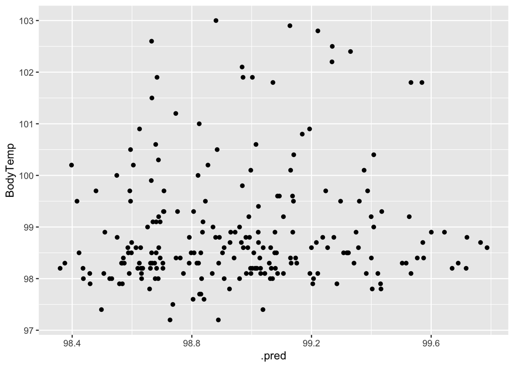

```r
# 8) Make diagnostic plots

#plot actual vs fitted
ggplot(data = aug_final_forest, aes(x = .pred, y = BodyTemp)) +
  geom_point()
```

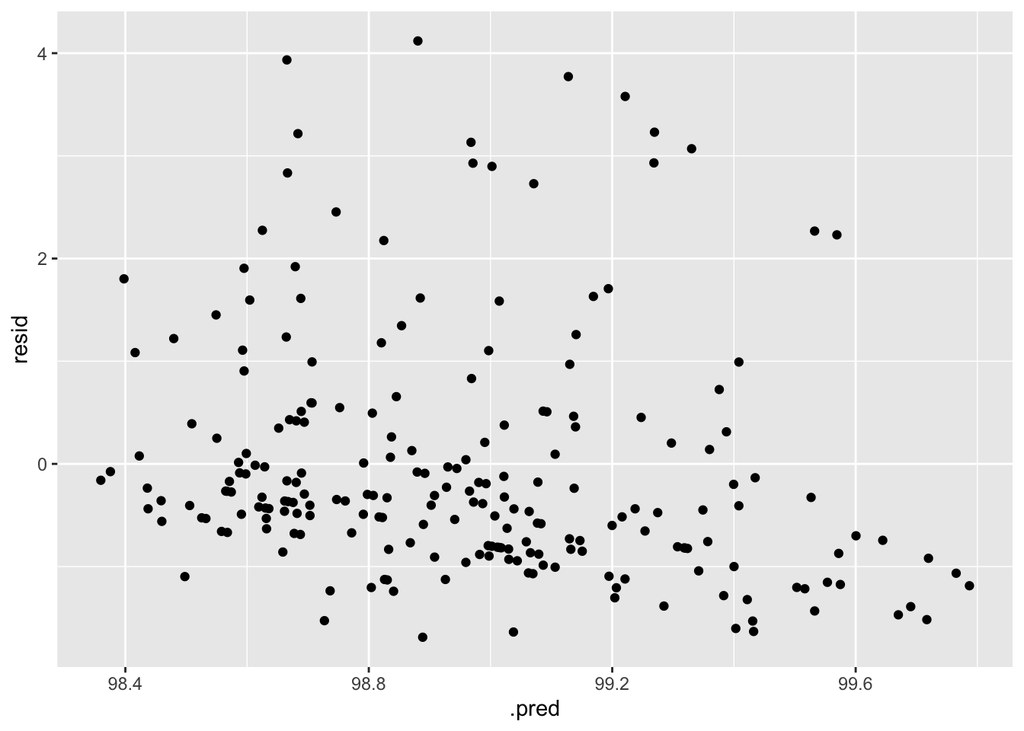

```r
#plot residuals vs fitted
aug_final_forest %>%
  mutate(resid = BodyTemp - .pred) %>%
  ggplot(aes(x = .pred, y = resid)) +
  geom_point()
```